DS 6030 | Fall 2024 | University of Virginia

# Homework #4: Trees and Random Forest

Author

**SOLUTIONS**

Published

Fall 2024

**Warning**

These solutions are only for the private use of the students of DS 6030 Fall 2024. Sharing of the solutions, posting on the internet, selling to a company, or possession by anyone outside of the class constitutes a violation of the honor policy.

# Required R packages and Directories

```r
data_dir = 'https://mdporter.github.io/teaching/data/' # data directory
library(tidyverse)    # functions for data manipulation
library(ranger)       # fast random forest implementation
library(modeldata)    # for the ames housing data
```

# Problem 1: Tree splitting metrics for classification

Consider the Gini index, classification error, and entropy impurity measures in a simple classification setting with two classes.

Create a single plot that displays each of these quantities as a function of $p_m$, the estimated probability of an observation in node $m$ being from class 1. The x-axis should display $p_m$, ranging from 0 to 1, and the y-axis should display the value of the Gini index, classification error, and entropy.

**Solution**

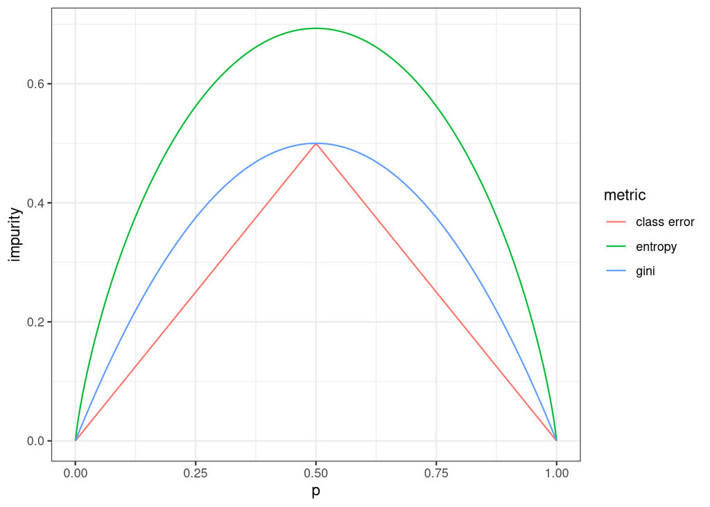

```r
scores = tibble(
          p = seq(0, 1, length=200),
          gini = 2*p*(1-p),
          `class error` =1-pmax(p, 1-p),
          entropy = {-p*log(p) - (1-p)*log(1-p)} %>% coalesce(0)
          )

scores %>%
  pivot_longer(cols = -p, names_to="metric", values_to="impurity") %>%
  ggplot(aes(p, impurity, color=metric)) + geom_line()
```

It is often helpful to scale the loss functions to make them more comparable (the optimization of a loss function will not be impacted by the scale). Here, the functions are rescaled such that the the max loss is one.

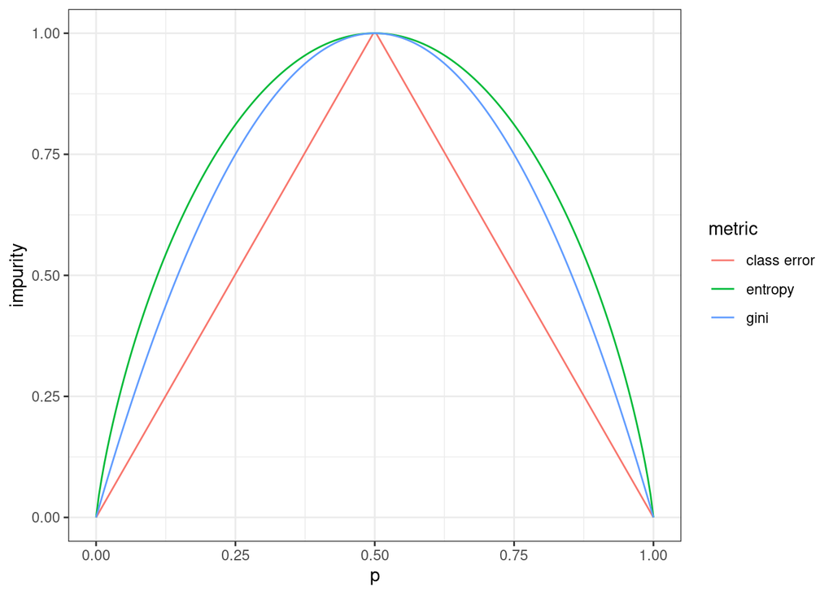

```r
scores %>%
  mutate_at(vars(-p), ~.x/max(.x)) %>%
  pivot_longer(cols = -p, names_to="metric", values_to="impurity") %>%
  ggplot(aes(p, impurity, color=metric)) + geom_line()
```

# Problem 2: Combining bootstrap estimates

Suppose we produce ten bootstrapped samples from a data set containing red and green classes. We then apply a classification tree to each bootstrapped sample and, for a specific value of $X$, produce the following 10 estimates of $\Pr(\text{Class is Red} \mid X=x)$: $\{0.2, 0.25, 0.3, 0.4, 0.4, 0.45, 0.7, 0.85, 0.9, 0.9\}$.

## a. Majority Vote

ISLR 8.2 describes the *majority vote* approach for making a hard classification from a set of bagged classifiers. What is the final classification for this example using majority voting?

**Solution**

In majority voting, each classifier makes a hard classification and the class that occurs the most is used as the final classification. The initial classifications using a threshold of $0.50$ is: Green, Green, Green, Green, Green, Green, Red, Red, Red, Red. The majority classification gives

```r
str_c("The majority vote decides: ",
      ifelse(mean(p_red > 0.50) >= 1/2, "Red", "Green")
)
```

```
[1] "The majority vote decides: Green"
```

## b. Average Probability

An alternative is to base the final classification on the average probability. What is the final classification for this example using average probability?

**Solution**

The average probability is 0.535. Under equal costs of mis-classification (using threshold of $0.50$) the final classification becomes

```r
str_c("The average probability decides: ",
      ifelse(mean(p_red) > 0.50, "Red", "Green")
)
```

```
[1] "The average probability decides: Red"
```

# Problem 3: Random Forest Tuning

Random forest has several tuning parameters that you will explore in this problem. We will use the `ames` housing data from the `modeldata` R package.

There are several R packages for Random Forest. The `ranger::ranger()` function is much faster than `randomForest::randomForest()` so we will use this one.

## a. Random forest (`ranger`) tuning parameters

List all of the random forest tuning parameters in the `ranger::ranger()` function. You don’t need to list the parameters related to computation, special models (e.g., survival, maxstat), or anything that won’t impact the predictive performance.

Indicate the tuning parameters you think will be most important to optimize?

**Solution**

Need to check the help:

```r
library(ranger)
?ranger
```

- Common tuning parameters
  - `num.trees` is the total number of trees in the forest.
  - `mtry` controls the number of variables to consider for splitting.
  - `min.node.size`, `min.bucket`, `max.depth` controls size of trees.
  - `replace`, `sample.fraction` are related to the data sampling for each tree.
  - `splitrule` controls the metric used to find the best split.
  - `respect.unordered.factors` controls how factors (i.e., categorical predictors) are handled.
- Other possible tuning parameters:
  - `case.weights`, `class.weights` allow for weighted evaluation.
  - `split.select.weights`, `always.split.variables` controls the variable sampling for splitting.
  - `regularization.factor`, `regularization.usedepth` attempt to encourage sparse variable selection by making it harder for unused variables to be chosen for splitting. This probably won’t have too much impact on prediction, but could influence variable importance results.
- Other non-tuning parameters:
  - `probability` allows outputting probabilities in terminal nodes.
  - `importance`, `scale.permutation.importance`, `local.importance` are related to variable importance.
  - `num.threads` is the number of CPU threads to use in growing the forest.
  - `seed` is the random seed used for all the random sampling (data and variables). Technically, you could treat this as a tuning parameter and try to find a seed that produced better predictions. But there are no patterns in the seed, so it would just be a random search.

The `mtry` parameter should be the most influential on performance as it controls the level of correlation between trees. The `num.trees` parameter should be set *large enough* to get the variance reduction benefit; you should not see much of a performance drop by using more trees (just like you wouldn’t expect a performance drop by using more bootstrap samples), so `num.trees` is not usually searched over.

It’s possible the other tuning parameters can help fine tune performance, but `mtry` is the big one to start with.

## b. Implement Random Forest

Use a random forest model to predict the sales price, `Sale_Price`. Use the default parameters and report the 10-fold cross-validation RMSE (square root of mean squared error).

**Solution**

```r
library(ranger)
data(ames, package = "modeldata") # load ames data

#-- Set-up Cross-validation
set.seed(2023)   # set seed to reproducible
K = 10           # number of folds
folds = rep(1:K, length=nrow(ames)) %>% sample() # make folds

#-- Run cross-validation
set.seed(1234)
SSE = numeric(K)
for(k in 1:K){
  test = (folds == k)
  train = (folds != k)
  rf = ranger(Sale_Price ~ ., data = ames[train, ])
  yhat = predict(rf, ames[test, ])$predictions
  SSE[k] = sum( (yhat - ames$Sale_Price[test])^2 )
}
MSE = sum(SSE) / nrow(ames)
(RMSE = sqrt(MSE) )
```

```
[1] 26980
```

This gave an RMSE of 26,980 using the default values of `mtry` = 8 and `num.trees` = 500.

## c. Random Forest Tuning

Now we will vary the tuning parameters of `mtry` and `min.bucket` to see what effect they have on performance.

- Use a range of reasonable `mtry` and `min.bucket` values.
  - The valid `mtry` values are $\{1,2, \ldots, p\}$ where $p$ is the number of predictor variables. However the default value of `mtry = sqrt(p) =` 8 is usually close to optimal, so you may want to focus your search around those values.
  - The default `min.bucket=1` will grow deep trees. This will usually work best if there are enough trees. But try some values larger and see how it impacts predictive performance.
  - Set `num.trees=1000`, which is larger than the default of 500.
- Use 5 times repeated out-of-bag (OOB) to assess performance. That is, run random forest 5 times for each tuning set, calculate the OOB MSE each time and use the average for the MSE associated with the tuning parameters.
- Use a single plot to show the average MSE as a function of `mtry` and `min.bucket`.
- Report the best tuning parameter combination.
- Note: random forest is a stochastic model; it will be different every time it runs due to the bootstrap sampling and random selection of features to consider for splitting. Set the random seed to control the uncertainty associated with the stochasticity.
- Hint: If you use the `ranger` package, the `prediction.error` element in the output is the OOB MSE.

**Solution**

We want to be careful to ensure that the same seed is set prior to running with each tuning set - otherwise the results will be dependent on the random seed rather than the tuning values!

```r
library(ranger)

#: grid for tuning
tune_grid = expand_grid(
  mtry = seq(4, 25, by = 2),
  min.bucket = seq(1, 8, by = 2)
)

M = 5  # number of repeats

#: Repeated OOB analysis
RMSE = tibble()               # initiate results df
for(m in 1:M) {
  # print(paste("starting m =", m, "of", M))
  for(i in 1:nrow(tune_grid)) {
    mtry = tune_grid$mtry[i]
    min.bucket = tune_grid$min.bucket[i]
    rf = ranger(Sale_Price~., data=ames,
                mtry = mtry, min.bucket = min.bucket,
                num.trees = 1000,
                seed = m)             # ensure same bagging for all mtry
    out = tibble(mtry, min.bucket,
           rmse = sqrt(rf$prediction.error),
           iter = m)
    RMSE = bind_rows(RMSE, out)
  }
}
```

```r
#-- Aggregate Results
RMSE_agg = RMSE %>%
  group_by(mtry, min.bucket) %>%
  summarize(
    n = n(),
    se = sd(rmse)/sqrt(n),
    rmse = mean(rmse),
    .groups="drop"
  )
```

```r
#-- Table of Results
RMSE_agg %>%
  slice_min(rmse, n = 6) %>%
  knitr::kable()
```

| mtry | min.bucket | n | se | rmse |
| --- | --- | --- | --- | --- |
| 16 | 1 | 5 | 33.8 | 25832 |
| 22 | 1 | 5 | 25.8 | 25976 |
| 24 | 1 | 5 | 39.3 | 25976 |
| 18 | 1 | 5 | 35.3 | 25985 |
| 20 | 1 | 5 | 24.9 | 25985 |
| 14 | 1 | 5 | 13.9 | 26042 |

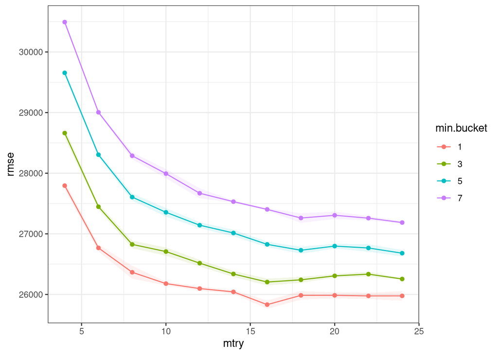

```r
#-- Plot Results
RMSE_agg %>%
  mutate(min.bucket = factor(min.bucket)) %>% # make into factor for plotting
  ggplot(aes(mtry, rmse, color=min.bucket)) +
  geom_point() +
  geom_line() +
  geom_ribbon(aes(ymin=rmse-2*se, ymax=rmse+2*se,
                  color=NULL, fill=min.bucket),
              alpha=.1, show.legend = FALSE)
```

This shows that the default `min.bucket=1` gives the best prediction for the ames data. The best performance occurs at `mtry =` 16.

Note on tuning the number of trees: the number of trees `num.trees` shouldn’t usually be tuned [Ref: Probst and Boulesteix, JMLR 2018. To Tune or Not to Tune the Number of Trees in Random Forest](https://jmlr.org/papers/volume18/17-269/17-269.pdf). Set it to some large number and spend time tuning the other more influential tuning parameters. How large should should `num.trees` be? The larger the value of `num.trees`, the longer the random forest takes to train and make predictions. Also, the storage size of the model increases. There may be practical constraints on these.